# Prosper Loan Data Exploration

## by Eevamaija Virtanen

## Preliminary Wrangling

This document explores a dataset containing 113,937 loans from Prosper.

### What is the structure of your dataset?

There are 113937 loans in the dataset with 81 variables. Most variables are numeric in nature, but the variables CreditGrade, LoanStatus and EmploymentStatus are categorical variables.

CreditGrade is an ordered variable with the following levels: NC, HR, E, D, C, B, A, AA (worst) ——> (best)

### What is/are the main feature(s) of interest in your dataset?

I'm most interested in figuring out what variables are best for predicting a loan's outcome such as default and also estimating the borrower's interest rate. It would be also interesting to see if there are differences between loan outcomes depending on how large the original loan amount was.

### What features in the dataset do you think will help support your investigation into your feature(s) of interest?

I expect that employment and salary will have some effect on the borrower's interest rate: the larger the salary, the lower the rate. I also think that these variables with employment status might have effects on the loan default, as well as debt to income ratio.

## Univariate Exploration

I'll start by looking at the distribution of the loan amounts.

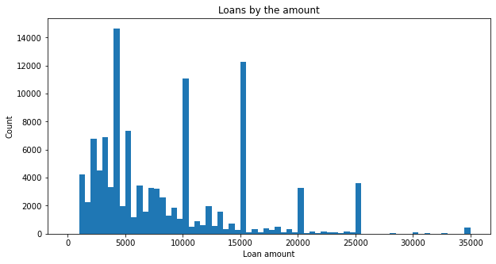

Next up, the interest rate.

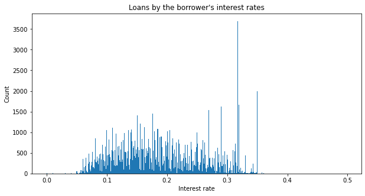

There seems to be a very large peak at 0.3177-0.3199 which is a lot higher than the mean 0.1929. The distribution looks a bit of bimodal. The small bin size shows that there are very large spikes in frequency at the bars with 0.001 precision.

Moving on to the loan statuses, credit grades and home ownerships.

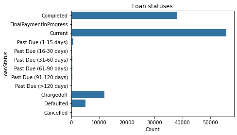

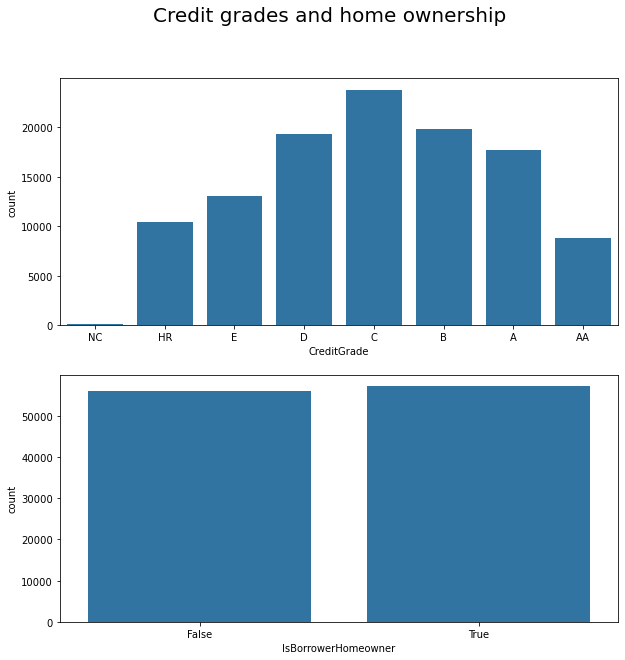

### Discuss the distribution(s) of your variable(s) of interest. Were there any unusual points? Did you need to perform any transformations?

Most of the loans are still current or already completed. There are also quite a few loans that have been charged off or defaulted.

Credit grades seems to fall under a normal distribution as expected.

There was no need for values to be transformed.

### Of the features you investigated, were there any unusual distributions? Did you perform any operations on the data to tidy, adjust, or change the form of the data? If so, why did you do this?

Interestingly, home ownership is nearly an equal 50/50.

I performed some cleaning of the data such as removing duplicates and merging the credit grade and prosper rating columns. The data and categories were the same but the credit grades were pre 2009 and prosper ratings after that. I made the merging to be able to make comparing the data easier.

## Bivariate Exploration

Starting this section with correlations between numeric variables in the data.

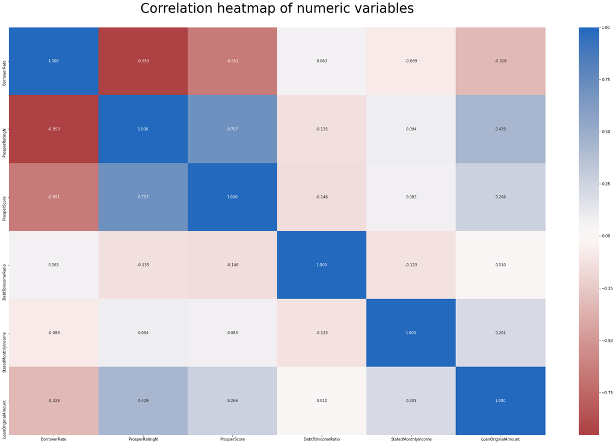

As expected, the 'ProsperRatingN'and 'ProsperScore' dimensions are highly correlated with one another, and both of them are also highly correlated with 'BorrowerRate' and somewhat correlated with the 'LoanOriginalAmount'.

Surprisingly, the correlation coefficient between 'StatedMonthlyIncome' and 'DebtToIncomeRatio' with other variables are very low.

Continuing the exploration with the numeric variables against the categorical variables.

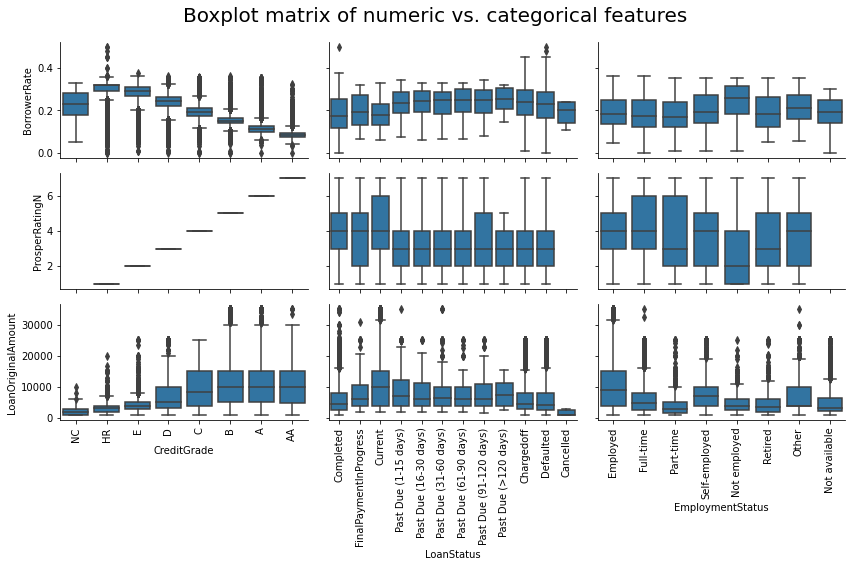

It appears that the borrower with the highest credit grades and prospect ratings have the lowest borrower's rates. Also it seems that the borrowers with lower borrower's rates are employed.

Next, comparing the categorical features against each other.

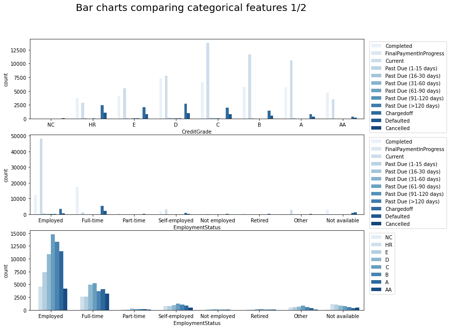

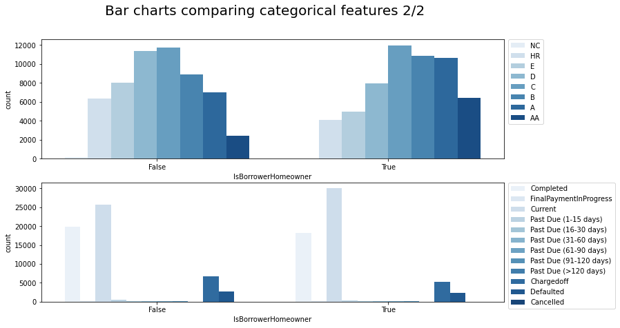

Most of the current borrowers are employed and have higher credit grades. Normal distribution of credit grades seems to be present with all the employment categories. Homeowners are mostly in the higher credit grade range and also represented less in the charged off and defaulted loan categories.

Continuing the study by comparing the distribution of categorical variables with numeric variables.

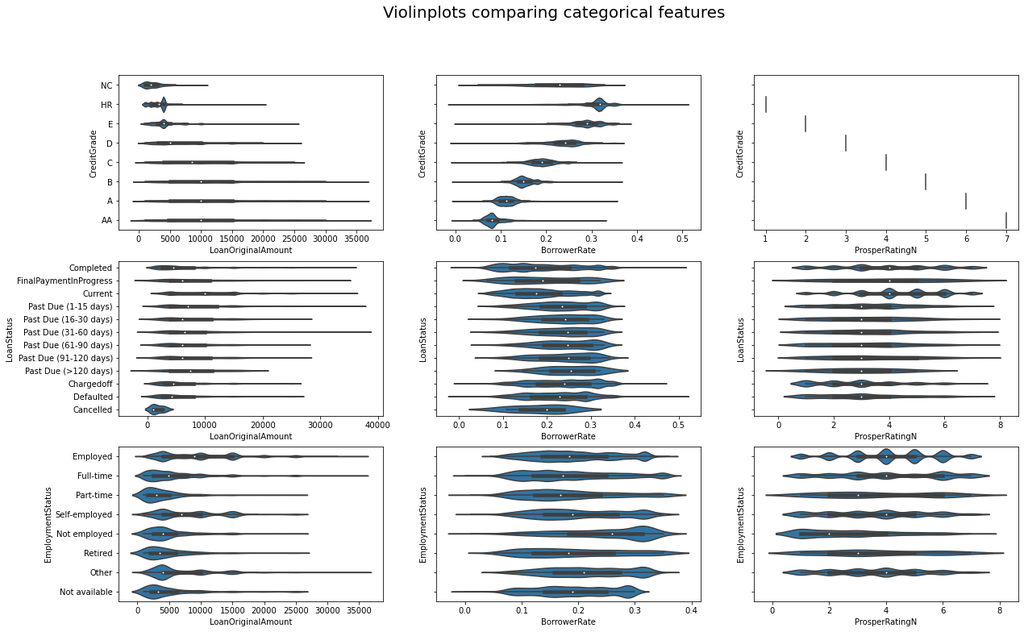

It is highly suggested in the violinplots that the borrower rate is higher with unemployed borrowers and also with the loans that end up being late with payments, charged off or defaulted. So the risk correlation seems evident with the interest rates. Loan amounts seem to be higher with the higher credit grades which seems to align with the risk estimation. Lower prosper rating also correlates to a loan ending up being charged off or defaulted so the risks are being noted already at the time of the lending decision.

Exploring next the most common occupations and possible connections with borrower's rates and prosper ratings.

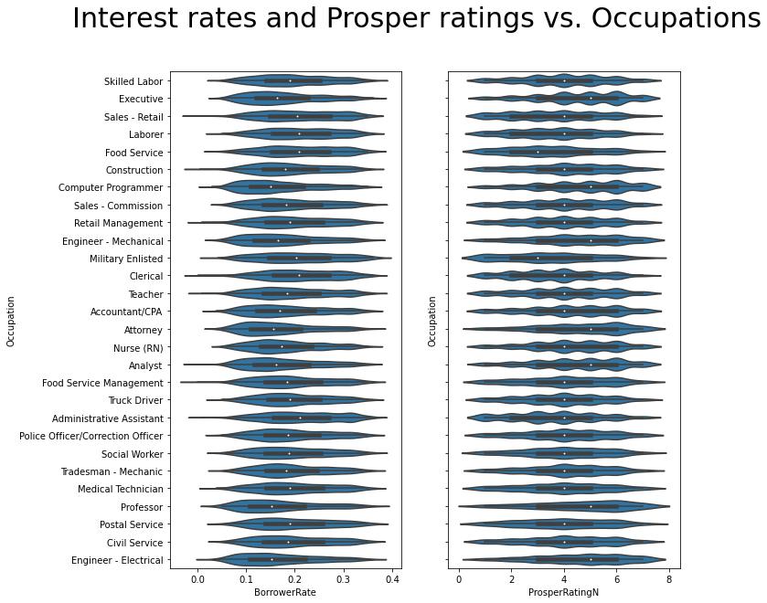

Attorneys, engineers, executives, computer programmers and professors have the lowest average interest rates in the top 30 most common professions within the data set. It seems that these professions also have higher prosper ratings.

Studying stated monthly income a bit further by removing 5% of the highest outliers. It could be that the data for some loan records could be the yearly income instead of monthly income which distorts the statistics.

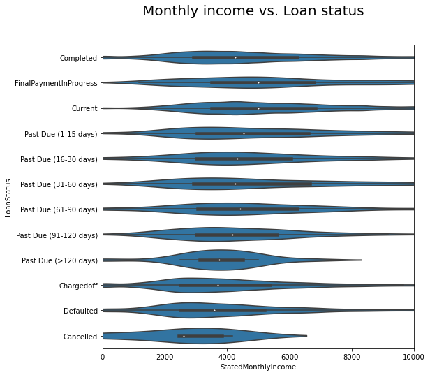

Lower monthly income seems to correlate with the loans chances of being defaulted or charged off.

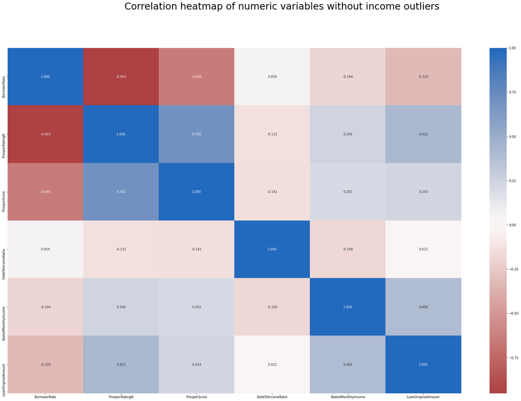

Plotting the correlation map without the income outliers shows now a higher correlation with the other variables and stated monthly income.

### Talk about some of the relationships you observed in this part of the investigation. How did the feature(s) of interest vary with other features in the dataset?

As expected, the credit grades/prosper ratings and prosper scores correlated with one another, and all of them are also correlated with interest rates and the loan amounts.

It appears that borrowers with lower interest rates have higher credit grades and prospect ratings, bigger loans, are employed and own a home. Most of the current borrowers are employed and have higher credit grades.

The borrowers with higher interest rates, lower prosper ratings, lower monthly income and who are not homeowners end up more often with being late with payments or the loan being defaulted or charged off.

### Did you observe any interesting relationships between the other features (not the main feature(s) of interest)?

Expected relationships were found in the association between the risk estimation and variables considered affecting the risk factor.

## Multivariate Exploration

I will explore in this part of the analysis how the credit grades affect the relationship between the loan amount and interest rate.

First heatmap grid is made of credit grades of the borrowers with defaulted loans.

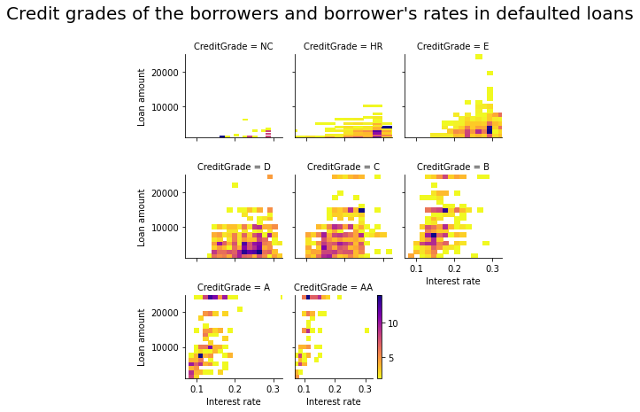

Second heatmap grid is made of credit grades of all the loan borrowers.

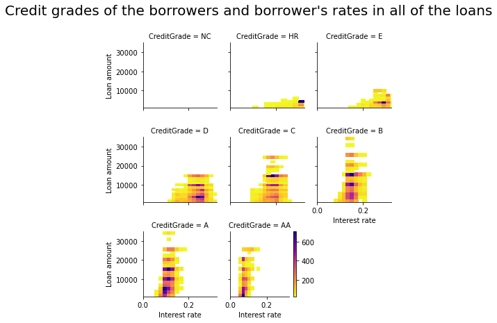

### Talk about some of the relationships you observed in this part of the investigation. Were there features that strengthened each other in terms of looking at your feature(s) of interest?

I investigated loan amounts against interest rates in this section by looking at varied credit grades. The multivariate exploration here showed that there is an effect of decreased interest rate on loans with the higher credit grades. Also, the higher the loan amount the lower the interest rate. Loans that ended up defaulted had a lower average credit grade already in the beginning.

### Were there any interesting or surprising interactions between features?

It seems like there's a systematic interaction effect between the investigated features. The defaulted loans seemed to have varied credit grades so that it wasn't as clear from that perspective that the loan would end up defaulted.